# Introduction to MSGPCA

MSGPCA decomposes each observations-by-features matrix into shared and local programs, $Y_m\approx F_{s,m}W_s^T+F_{l,m}W_{l,m}^T$. Shared loadings are common; local loadings vary by slice. Loading columns are orthonormal and local loadings are orthogonal to the shared space. Signs, rotations and allocation ambiguities remain. Scores are graph-smoothed using sparse shifted-Laplacian solves.

## Inputs and preprocessing

Provide a list of abundance matrices, with common molecular feature identities in identical order, and corresponding coordinate matrices with matching rows. Slice sizes and coordinates may differ; no alignment is necessary. The fitter never normalizes, centers, scales or transforms inputs. Choose preprocessing appropriate to the assay. Sparse inputs are accepted, but initialization, residuals and feature covariances can densify.

```r
library(MSGPCA)
sim <- simulation_gg_blocks(nside=6,Jsp=12,Jmix=24,Jns=12,seed=101)
Y <- lapply(sim$Y_list,log1p)
fit <- MSGPCA(Y,sim$locs_list,n_shared=5,n_local=2,
              lambda_shared=.3,lambda_local=.1,seed=101,verbose=FALSE)
summary(fit)
```

```
#> $parameters
#> $parameters$n_shared
#> [1] 5
#>
#> $parameters$n_local
#> [1] 2
#>
#> $parameters$k_shared
#> [1] 4
#>
#> $parameters$k_local
#> [1] 6
#>
#> $parameters$lambda_shared
#> [1] 0.3
#>
#> $parameters$lambda_local
#> [1] 0.1
#>
#> $parameters$graph_type
#> [1] "mutual"
#>
#> $parameters$max_iter
#> [1] 100
#>
#> $parameters$min_iter
#> [1] 10
#>
#> $parameters$tol
#> [1] 1e-05
#>
#> $parameters$seed
#> [1] 101
#>
#> $parameters$covariance_cache
#> [1] TRUE
#>
#> $parameters$covariance_estimate_bytes
#> [1] 55296
#>
```

[output cut: 17 more lines]

```
#> $objective_increases$number
#> [1] 0
#>
#> $objective_increases$maximum
#> [1] 0
#>
#> $objective_increases$magnitudes
#> numeric(0)
#>
#>
#> $timings
#>          graph.elapsed  factorization.elapsed precomputation.elapsed
#>                  0.014                  0.008                  0.001
#> initialization.elapsed   optimization.elapsed          total.elapsed
#>                  0.011                  0.265                  0.299
```

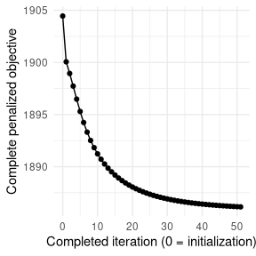

```r
plot_convergence(fit)
```

## Graphs and diagnostics

Mutual k-NN is default; `graph_type='union'` includes either directed neighbor relation. `k_shared` and `k_local` specify separate graph sizes, while `n_shared` and `n_local` specify factor dimensions. Supplied graph entries are combinatorial Laplacians, or `list(type='adjacency',matrix=A)`. Disconnected components and isolated vertices are supported. With zero smoothing and no coordinates, active scores are unregularized. Zero factor dimension disables a component. Diagnostics include initialization as iteration zero, every complete penalized objective and increases; the original shared update does not guarantee monotonic descent. Final scores and loadings always describe the same state.

## Spatial domain detection

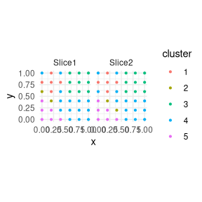

```r
gmm <- cluster_MSGPCA(fit,5,method='gmm',seed=101)
km <- cluster_MSGPCA(fit,5,method='kmeans',seed=101)
plot_clusters(gmm)
```

```r
head(gmm$raw[[1]])
```

```
#> [1] "4" "1" "4" "3" "3" "3"
```

```r
head(gmm$refined[[1]])
```

```
#> [1] "4" "1" "4" "3" "3" "3"
```

Shared clustering pools scores across slices; local clustering is independent and its cluster identifiers are not aligned. Scores are not implicitly scaled. Use `factors=2:5` only with a scientific justification fixed independently of truth. GMM covariance models are selected by mclust and retained in `gmm_model`.

Refinement is adapted from SpatialPCA (Shang and Zhou, 2022, doi:10.1038/s41467-022-34879-1), distributed under GPL >=3. It uses one sequential pass, the focal observation and four (`square`) or six (`hexagon`) neighbors, with the original strict frequency rule. Ties use observation order. Conventional Visium uses hexagon. The shape does not validate tissue geometry. Duplicates and insufficient observations are errors. The default exact k-NN/radius-query implementation retrieves all boundary ties and resolves them by observation order; a rowwise reference is available via `engine='reference'`. Memory is linear; worst-case distance work is quadratic. Set `refine=FALSE` to retain raw assignments only.

## Denoising and metafeatures

```r
shared <- reconstruct_MSGPCA(fit,'shared',features=1:4)
local <- reconstruct_MSGPCA(fit,'local',features=1:4)
all <- reconstruct_MSGPCA(fit,features=1:4)
stopifnot(isTRUE(all.equal(all[[1]],shared[[1]]+local[[1]])))
scores <- get_scores(fit,'shared')
loadings <- get_loadings(fit,'shared')
head(sort(loadings[,1],decreasing=TRUE))
```

```
#>      Gene43      Gene46      Gene45      Gene17       Gene6      Gene10
#> -0.03938799 -0.04423298 -0.04714692 -0.09558602 -0.09790863 -0.10104730
```

```r
head(sort(loadings[,1],decreasing=FALSE))
```

```
#>     Gene36     Gene14     Gene27     Gene19     Gene18     Gene33
#> -0.1834678 -0.1806242 -0.1790905 -0.1783539 -0.1775263 -0.1774822
```

```r
head(sort(abs(loadings[,1]),decreasing=TRUE))
```

```
#>    Gene36    Gene14    Gene27    Gene19    Gene18    Gene33
#> 0.1834678 0.1806242 0.1790905 0.1783539 0.1775263 0.1774822
```

[figure not shown]

```r
plot_factors(fit,'shared')
```

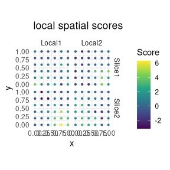

```r
plot_factors(fit,'local')
```

[figure not shown]

```r
plot_loadings(fit,top=8)
```

Loadings define molecular metafeatures; scores show their spatial activity. Large loadings do not imply statistical significance. Local factor column numbers across slices do not imply common programs. Reconstructions remain on the supplied scale and are not automatically original counts. There is no unobserved-location prediction method.